# Formatos de Fecha y Tiempos

## Introducción

`R` proporciona varias opciones para tratar con datos de fecha y fecha/hora. La función `as.Date` del paquete `base` maneja las fechas pero sin tiempos, existe el paquete `chron` que trabaja con fecha y tiempos, pero no controla la zona horaria; y las clases `POSIXct` y `POSIXlt`, que incorpora la norma POSIX, sirven para trabajar con tiempo fechas y zonas horarias.

```r
install.packages("chron",dependencies = T)
```

```r
Sys.Date()
```

```
## [1] "2020-07-14"
```

```r
Sys.time()
```

```
## [1] "2020-07-14 19:53:40 -05"
```

```r
Sys.timezone()
```

```
## [1] "America/Bogota"
```

```r
Sys.getlocale()
```

```
## [1] "LC_COLLATE=Spanish_Colombia.1252;LC_CTYPE=Spanish_Colombia.1252;LC_MONETARY=Spanish_Colombia.1252;LC_NUMERIC=C;LC_TIME=Spanish_Colombia.1252"
```

```r
methods(as.Date)
```

```
## [1] as.Date.character as.Date.default   as.Date.factor    as.Date.numeric
## [5] as.Date.POSIXct   as.Date.POSIXlt
## see '?methods' for accessing help and source code
```

```r
args(as.Date.character)
```

```
## function (x, format, tryFormats = c("%Y-%m-%d", "%Y/%m/%d"),
##     optional = FALSE, ...)
## NULL
```

El argumento `format=` indica el tipo de formato de fecha que se quiere usar.

- `%d`: día del mes (número decimal)
- `%m`: Mes (número decimal)
- `%b`: Mes (nombre abreviado)
- `%B`: Mes (nombre completo)
- `%y`: Año (dos dígitos)
- `%Y`: Año (cuatro dígitos)

```r
as.Date("1949-8-26")
```

```
## [1] "1949-08-26"
```

```r
as.Date("1985/10/15")
```

```
## [1] "1985-10-15"
```

```r
as.Date("6/18/1932", format="%m/%d/%Y")
```

```
## [1] "1932-06-18"
```

```r
as.Date("Mayo 1, 1886", format="%B %d, %Y")
```

```
## [1] "1886-05-01"
```

```r
as.Date("15mar.92", format="%d%b%y")
```

```
## [1] "1992-03-15"
```

Internamente los objetos tipo `Date` guarda un número de días comenzando desde Enero 01 de 1970, con la función `as.numeric` se puede coercionar la fecha para convertirla en número.

```r
x <- c("1960-1-1","1969-1-1","1970-1-1","1971-1-1","1980-1-1")
(y <- as.Date(x))
```

```
## [1] "1960-01-01" "1969-01-01" "1970-01-01" "1971-01-01" "1980-01-01"
```

```r
as.numeric(y)
```

```
## [1] -3653  -365     0   365  3652
```

Para extraer los componentes de fechas se puede emplear las funciones `weekdays`, `months`, `days` o `quarters`.

```r
# Fechas de nacimiento de Estadísticos importantes en la historia
library(chron)
(Dnac <- c(tukey=as.Date('1915-06-16'),fisher=as.Date('1890-02-17'),
          cramer=as.Date('1893-09-25'),kendall=as.Date('1907-09-06')))
```

```
##        tukey       fisher       cramer      kendall
## "1915-06-16" "1890-02-17" "1893-09-25" "1907-09-06"
```

```r
weekdays(Dnac)
```

```
##       tukey      fisher      cramer     kendall
## "miércoles"     "lunes"     "lunes"   "viernes"
```

```r
months(Dnac)
```

```
##        tukey       fisher       cramer      kendall
##      "junio"    "febrero" "septiembre" "septiembre"
```

```r
days(Dnac)
```

```
## [1] 16 17 25 6
## 31 Levels: 1 < 2 < 3 < 4 < 5 < 6 < 7 < 8 < 9 < 10 < 11 < 12 < 13 < ... < 31
```

```r
quarters(Dnac)
```

```
## [1] "Q2" "Q1" "Q3" "Q3"
```

La función `chron` sirve para trabaja con fechas y tiempos, los formatos que reciben son.

**Fechas**

- `m`: Mes (número decimal)
- `d`: Días del mes (número decimal)
- `y`: Año (cuatro dígitos)
- `mon`: Mes (nombre abreviado)
- `month`: Mes (nombre completo)

**Tiempos**

- `h`: Hora
- `m`: Minutos
- `s`: Segundos

```r
(fechas <- dates(c("06/09/02","01/29/03",
                  "09/04/02","11/13/02",
                  "07/07/02")))
```

```
## [1] 06/09/02 01/29/03 09/04/02 11/13/02 07/07/02
```

```r
(tiempos <- times(c("12:45:40","09:30:40",
                    "16:45:40","20:00:40",
                    "17:30:40")))
```

```
## [1] 12:45:40 09:30:40 16:45:40 20:00:40 17:30:40
```

```r
chron(dates. = fechas, times. = tiempos)
```

```
## [1] (06/09/02 12:45:40) (01/29/03 09:30:40) (09/04/02 16:45:40)
## [4] (11/13/02 20:00:40) (07/07/02 17:30:40)
```

```r
chron(dates. = fechas, times. = tiempos,format = c("y-m-d","h:m:s"))
```

```
## [1] (02-06-09 12:45:40) (03-01-29 09:30:40) (02-09-04 16:45:40)
## [4] (02-11-13 20:00:40) (02-07-07 17:30:40)
```

```r
chron(dates. = fechas, times. = tiempos,format = c("y-month-d","h:m:s"))
```

```
## [1] (2002-June-09 12:45:40)      (2003-January-29 09:30:40)
## [3] (2002-September-04 16:45:40) (2002-November-13 20:00:40)
## [5] (2002-July-07 17:30:40)
```

Hay dos clases de fecha/hora de tipo POSIX, que difieren en la forma en que los valores se almacenan internamente. La clase `POSIXct` almacena los valores fecha/hora como el número de segundos desde el 1 de Enero de 1970, mientras que la clase `POSIXlt` los almacena como una lista con elementos para el segundo, minuto, hora, día, mes y año, entre otros. A menos que necesite la naturaleza de lista de la clase `POSIXlt`, la clase `POSIXct` es la opción habitual para almacenar fechas en `R`.

El formato de entrada predeterminado para las fechas POSIX consiste en el año, seguido del mes y el día, separados por barras o guiones; para los valores de fecha/hora, la fecha puede ir seguida de un espacio en blanco y una hora en la forma hora:minutos:segundos o hora:minutos.

```r
dts <- c ("2005-10-21 18:47:22", "2005-12-24 16:39:58",
           "2005-10-28 07:30:05 PDT")
as.POSIXlt(dts)
```

```
## [1] "2005-10-21 18:47:22 -05" "2005-12-24 16:39:58 -05"
## [3] "2005-10-28 07:30:05 -05"
```

Si la fecha/hora de entrada se almacenan como el número de segundos desde el 1 de Enero de 1970, puede crear valores de fecha POSIX asignando la clase apropiada directamente a esos valores. Dado que la mayoría de las funciones de manipulación de fechas se refieren a la clase psuedo `POSIXt`, asegúrese de incluirla como el primer miembro del atributo de clase.

```r
dts <- c(1127056501,1104295502,1129233601,1113547501,
         1119826801,1132519502,1125298801,1113289201)
mydates <- dts
class(mydates) <- c('POSIXt','POSIXct')
mydates
```

```
## [1] "2005-09-18 10:15:01 -05" "2004-12-28 23:45:02 -05"
## [3] "2005-10-13 15:00:01 -05" "2005-04-15 01:45:01 -05"
## [5] "2005-06-26 18:00:01 -05" "2005-11-20 15:45:02 -05"
## [7] "2005-08-29 02:00:01 -05" "2005-04-12 02:00:01 -05"
```

- `%a`: Día de la semana abreviado
- `%A`: Día de la semana completo
- `%b`: Mes abreviado
- `%B`: Mes completo
- `%c`: Fecha y hora específicas de la localidad
- `%d`: Fecha decimal
- `%H`: Horas decimales (24 horas)
- `%I`: Horas decimales (12 horas)
- `%j`: Día decimal del año
- `%m`: Mes decimal
- `%M`: Minuto decimal
- `%p`: Localidad específica de AM/PM
- `%S`: Segundo decimal
- `%U`: Decimal semana del año (a partir del domingo)
- `%w`: Decimal día de la semana (0 = domingo)
- `%W`: Decimal semana del año (a partir del lunes)
- `%x`: Fecha específica de la localidad
- `%X`: Tiempo específico de la localidad
- `%y`: Año de 2 dígitos
- `%Y`: Año de 4 dígitos
- `%z`: Comparación con GMT
- `%Z`: Zona horaria (`character`)

```r
args(strptime)
```

```
## function (x, format, tz = "")
## NULL
```

```r
args(ISOdate)
```

```
## function (year, month, day, hour = 12, min = 0, sec = 0, tz = "GMT")
## NULL
```

```r
strptime('16/Oct/2005:07:51:00',format='%d/%b/%Y:%H:%M:%S')
```

```
## [1] NA
```

```r
ISOdate(2005,10,21,18,47,22,tz="PDT")
```

```
## [1] "2005-10-21 18:47:22 GMT"
```

```r
data.frame(OlsonNames())
```

| OlsonNames.. |
| --- |
| Africa/Abidjan |
| Africa/Accra |
| Africa/Addis_Ababa |
| Africa/Algiers |
| Africa/Asmara |
| Africa/Asmera |
| Africa/Bamako |
| Africa/Bangui |
| Africa/Banjul |
| Africa/Bissau |

[output cut: 583 more lines]

```r
(fecha <- ISOdate(2005, 10, 21, 18, 47, 22, tz = "VEN"))
```

```
## [1] "2005-10-21 18:47:22 GMT"
```

```r
format(fecha,'%A, %B %d, %Y %H:%M:%S')
```

```
## [1] "viernes, octubre 21, 2005 18:47:22"
```

```r
(b1 <- ISOdate(1977,7,13))
```

```
## [1] "1977-07-13 12:00:00 GMT"
```

```r
(b2 <- ISOdate(2003,8,14))
```

```
## [1] "2003-08-14 12:00:00 GMT"
```

```r
b2 - b1
```

```
## Time difference of 9528 days
```

```r
difftime(b2,b1,units='weeks')
```

```
## Time difference of 1361.143 weeks
```

```r
difftime(b2,b1,units='mins')
```

```
## Time difference of 13720320 mins
```

```r
difftime(b2,b1,units='secs')
```

```
## Time difference of 823219200 secs
```

```r
seq(as.Date('1976-7-4'),by='days',length=10)
```

```
##  [1] "1976-07-04" "1976-07-05" "1976-07-06" "1976-07-07" "1976-07-08"
##  [6] "1976-07-09" "1976-07-10" "1976-07-11" "1976-07-12" "1976-07-13"
```

```r
seq(as.Date('1976-7-4'),by='years',length=10)
```

```
##  [1] "1976-07-04" "1977-07-04" "1978-07-04" "1979-07-04" "1980-07-04"
##  [6] "1981-07-04" "1982-07-04" "1983-07-04" "1984-07-04" "1985-07-04"
```

```r
seq(as.Date('2000-6-1'),to=as.Date('2000-8-1'),by='2 weeks')
```

```
## [1] "2000-06-01" "2000-06-15" "2000-06-29" "2000-07-13" "2000-07-27"
```

## Paquete `lubridate`

El paquete `lubridate` es parte de la familia `tidyverse`, según sus autores “`lubridate` tiene una sintaxis consistente y memorable, que hace que trabajar con las fechas sea divertido en lugar de frustrante”."

```r
install.packages("lubridate", dependencies = T)
```

```r
library(lubridate)
(hoy <- today())
```

```
## [1] "2020-07-14"
```

```r
year(hoy)
```

```
## [1] 2020
```

```r
month(hoy)
```

```
## [1] 7
```

```r
day(hoy)
```

```
## [1] 14
```

```r
wday(hoy)
```

```
## [1] 3
```

```r
wday(hoy,label = T)
```

```
## [1] mar\\.
## Levels: dom\\. < lun\\. < mar\\. < mié\\. < jue\\. < vie\\. < sáb\\.
```

```r
mday(hoy)
```

```
## [1] 14
```

```r
yday(hoy)
```

```
## [1] 196
```

```r
(ya <- now())
```

```
## [1] "2020-07-14 19:53:41 -05"
```

```r
hour(ya)
```

```
## [1] 19
```

```r
minute(ya)
```

```
## [1] 53
```

```r
second(ya)
```

```
## [1] 41.69896
```

```r
(fecha <- ymd("1979-06-12"))
```

```
## [1] "1979-06-12"
```

```r
class(fecha)
```

```
## [1] "Date"
```

```r
ymd("1989 May 17")
```

```
## [1] "1989-05-17"
```

```r
mdy("March 12, 1975")
```

```
## [1] "1975-03-12"
```

```r
dmy(25081985)
```

```
## [1] "1985-08-25"
```

```r
ymd("1920/1/2")
```

```
## [1] "1920-01-02"
```

```r
dt1 <- '2014-08-23 17:23:02'
ymd_hms(dt1)
```

```
## [1] "2014-08-23 17:23:02 UTC"
```

```r
hms("03:22:14")
```

```
## [1] "3H 22M 14S"
```

```r
update(ya, hours = 8, minutes = 34, seconds = 55)
```

```
## [1] "2020-07-14 08:34:55 -05"
```

```r
update(ymd_hms(dt1),year=2019,hours=12,minutes=56,seconds=24)
```

```
## [1] "2019-08-23 12:56:24 UTC"
```

```r
now("America/New_York")
```

```
## [1] "2020-07-14 20:53:41 EDT"
```

```r
now("Japan")
```

```
## [1] "2020-07-15 09:53:41 JST"
```

```r
now("Europe/Andorra")
```

```
## [1] "2020-07-15 02:53:41 CEST"
```

```r
(CABA <- now("America/Buenos_Aires"))
```

```
## [1] "2020-07-14 21:53:41 -03"
```

```r
CABA + days(2)
```

```
## [1] "2020-07-16 21:53:41 -03"
```

```r
CABA + hours(10) + minutes(35)
```

```
## [1] "2020-07-15 08:28:41 -03"
```

```r
with_tz(CABA,"US/Alaska")
```

```
## [1] "2020-07-14 16:53:41 AKDT"
```

```r
with_tz(CABA + hours(10) + minutes(35),"America/Bogota")
```

```
## [1] "2020-07-15 06:28:41 -05"
```

```r
(antes <- mdy("06-17-2008", tz = "Singapore"))
```

```
## [1] "2008-06-17 +08"
```

```r
(cuanto <- interval(antes,CABA))
```

```
## [1] 2008-06-17 +08--2020-07-15 08:53:41 +08
```

```r
as.period(cuanto)
```

```
## [1] "12y 0m 28d 8H 53M 41.7669699192047S"
```

```r
antes %--% CABA
```

```
## [1] 2008-06-17 +08--2020-07-15 08:53:41 +08
```

```r
as.duration(cuanto)
```

```
## [1] "381142421.76697s (~12.08 years)"
```

```r
cuanto/dweeks(1)
```

```
## [1] 630.1958
```

```r
cuanto/dweeks(5)
```

```
## [1] 126.0392
```

```r
cuanto/dhours(1)
```

```
## [1] 105872.9
```

```r
cuanto/dhours(12)
```

```
## [1] 8822.741
```

```r
cuanto/dminutes(1)
```

```
## [1] 6352374
```

```r
cuanto/dminutes(30)
```

```
## [1] 211745.8
```

```r
cuanto/dyears(1)
```

```
## [1] 12.07767
```

```r
cuanto/dyears(3)
```

```
## [1] 4.025892
```

```r
start <- c("2012-08-21", "2012-09-01", "2012-08-15", "2012-09-18")
end <- c("2012-09-16", "2012-09-06", "2012-08-22", "2012-10-11")
(elapsed.time <- start %--% end)
```

```
## [1] 2012-08-21 UTC--2012-09-16 UTC 2012-09-01 UTC--2012-09-06 UTC
## [3] 2012-08-15 UTC--2012-08-22 UTC 2012-09-18 UTC--2012-10-11 UTC
```

```r
mean(as.duration(elapsed.time) / dweeks(1))
```

```
## [1] 2.178571
```

## Ejemplo

La siguiente base de datos es una recolección de registros de temperatura de un río cada 15 minutos realizada por el [*NF American River*](https://raw.githubusercontent.com/gge-ucd/wRangling_Seminar/master/data/2015_NFA_solinst_08_05.csv). Este conjunto de datos tiene 35.038 observaciones de temperatura del agua y etapa (información del transductor de presión).

```r
datos <- read.csv("https://raw.githubusercontent.com/gge-ucd/wRangling_Seminar/master/data/2015_NFA_solinst_08_05.csv", skip=13)
library(lubridate)
library(dplyr)
datos
```

| Date | Time | ms | Level | Temperature |
| --- | --- | --- | --- | --- |
| 2014/08/05 | 11:00:00 | 0 | 0.8245 | 23.069 |
| 2014/08/05 | 11:15:00 | 0 | 1.1457 | 22.023 |
| 2014/08/05 | 11:30:00 | 0 | 1.1485 | 22.030 |
| 2014/08/05 | 11:45:00 | 0 | 1.1482 | 22.035 |
| 2014/08/05 | 12:00:00 | 0 | 1.1504 | 22.033 |
| 2014/08/05 | 12:15:00 | 0 | 1.1495 | 22.028 |
| 2014/08/05 | 12:30:00 | 0 | 1.1533 | 22.019 |
| 2014/08/05 | 12:45:00 | 0 | 1.1531 | 22.000 |
| 2014/08/05 | 13:00:00 | 0 | 1.1535 | 21.974 |
| 2014/08/05 | 13:15:00 | 0 | 1.1560 | 21.952 |

[output cut: 9990 more lines]

```r
summary(datos)
```

```
##          Date             Time             ms        Level
##  2014/08/06:   96   00:00:00:  365   Min.   :0   Min.   :0.7718
##  2014/08/07:   96   00:15:00:  365   1st Qu.:0   1st Qu.:1.1190
##  2014/08/08:   96   00:30:00:  365   Median :0   Median :1.3135
##  2014/08/09:   96   00:45:00:  365   Mean   :0   Mean   :1.3791
##  2014/08/10:   96   01:00:00:  365   3rd Qu.:0   3rd Qu.:1.5235
##  2014/08/11:   96   01:15:00:  365   Max.   :0   Max.   :4.7376
##  (Other)   :34462   (Other) :32848
##   Temperature
##  Min.   : 1.724
##  1st Qu.: 8.197
##  Median :13.258
##  Mean   :14.291
##  3rd Qu.:20.960
##  Max.   :28.748
##
```

```r
names(datos)
```

```
## [1] "Date"        "Time"        "ms"          "Level"       "Temperature"
```

```r
datos$datetime <- paste0(datos$Date, " ", datos$Time)
datos$datetime <- ymd_hms(datos$datetime)
library(magrittr) # para usar " %<>% "
library(ggplot2)
datos %<>% # Qué hace esto?
  mutate(yr = year(datetime),
         mon = month(datetime),
         wk = week(datetime),
         DOY = yday(datetime),
         hr = hour(datetime))
datos
```

| Date | Time | ms | Level | Temperature | datetime | yr | mon | wk | DOY | hr |
| --- | --- | --- | --- | --- | --- | --- | --- | --- | --- | --- |
| 2014/08/05 | 11:00:00 | 0 | 0.8245 | 23.069 | 2014-08-05 11:00:00 | 2014 | 8 | 31 | 217 | 11 |
| 2014/08/05 | 11:15:00 | 0 | 1.1457 | 22.023 | 2014-08-05 11:15:00 | 2014 | 8 | 31 | 217 | 11 |
| 2014/08/05 | 11:30:00 | 0 | 1.1485 | 22.030 | 2014-08-05 11:30:00 | 2014 | 8 | 31 | 217 | 11 |
| 2014/08/05 | 11:45:00 | 0 | 1.1482 | 22.035 | 2014-08-05 11:45:00 | 2014 | 8 | 31 | 217 | 11 |
| 2014/08/05 | 12:00:00 | 0 | 1.1504 | 22.033 | 2014-08-05 12:00:00 | 2014 | 8 | 31 | 217 | 12 |
| 2014/08/05 | 12:15:00 | 0 | 1.1495 | 22.028 | 2014-08-05 12:15:00 | 2014 | 8 | 31 | 217 | 12 |
| 2014/08/05 | 12:30:00 | 0 | 1.1533 | 22.019 | 2014-08-05 12:30:00 | 2014 | 8 | 31 | 217 | 12 |
| 2014/08/05 | 12:45:00 | 0 | 1.1531 | 22.000 | 2014-08-05 12:45:00 | 2014 | 8 | 31 | 217 | 12 |
| 2014/08/05 | 13:00:00 | 0 | 1.1535 | 21.974 | 2014-08-05 13:00:00 | 2014 | 8 | 31 | 217 | 13 |
| 2014/08/05 | 13:15:00 | 0 | 1.1560 | 21.952 | 2014-08-05 13:15:00 | 2014 | 8 | 31 | 217 | 13 |

[output cut: 9990 more lines]

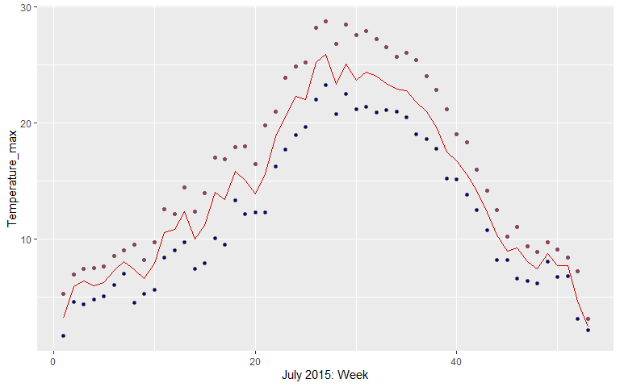

```r
datos %>%  select(Level, Temperature, wk) %>%
  group_by(wk) %>%
  summarise_each(funs(mean, max, min)) %>%
  ggplot() +
  geom_point(aes(x=wk,y=Temperature_max),color="gray40",fill="maroon",pch=21)+
  geom_line(aes(x=wk,y=Temperature_mean),color="red3")+
  geom_point(aes(x=wk,y=Temperature_min),color="gray40",fill="navyblue",pch=21)+
  xlab("July 2015: Week")
```

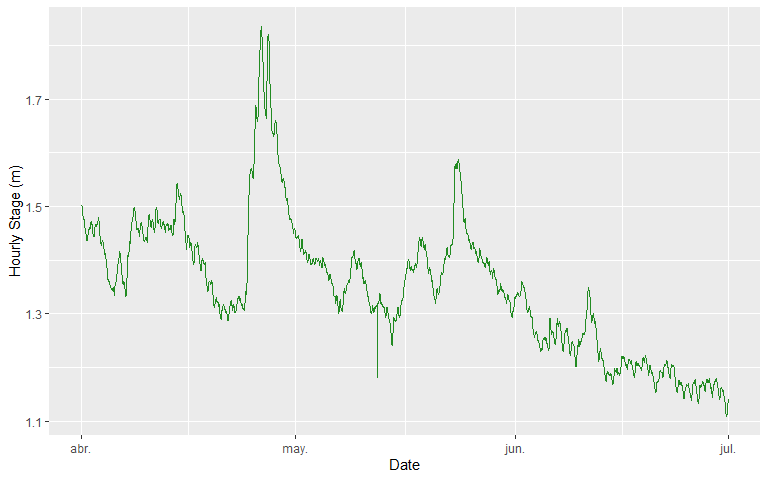

```r
datos %>%  filter(mon>=4 & mon<=6) %>%
  select(Level, DOY, hr, yr) %>%
  group_by(yr, DOY, hr) %>%
  summarise(mean_Level=mean(Level)) %>%
  mutate(datetimes = ymd_hms(strptime(paste0(yr,"-",DOY," ",hr, ":00"),format="%Y-%j %H:%M"))) %>%
  ggplot()+
  geom_line(aes(x=datetimes, y=mean_Level),color="forestgreen")+
  xlab("Date") + ylab("Hourly Stage (m)")
```

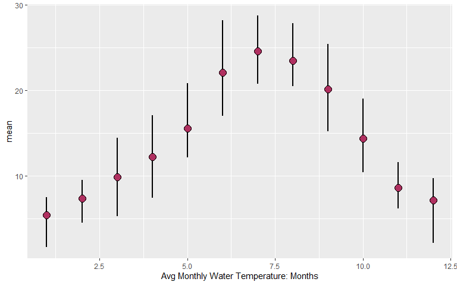

```r
datos %>%
  select(Temperature, mon) %>%
  group_by(mon) %>%
  summarise_each(funs(mean, max, min)) %>%
  ggplot()+
  geom_pointrange(aes(x=mon,y=mean,ymax=max,ymin=min),fill="maroon",size=1,pch=21)+
  xlab("Avg Monthly Water Temperature: Months")
```

En los siguientes links se encuentran guías útiles para trabajar modelos series de tiempo.

- [Little Book of R for Time Series!](https://a-little-book-of-r-for-time-series.readthedocs.io/en/latest/index.html)
- [Tidy time series forecasting with fable](https://tidyverts.github.io/tidy-forecasting-principles/)
- [Forecast: fable](https://mitchelloharawild.com/fable-tfeam/#1)
- [Climate change: Modeling](https://rethinking.rbind.io/2019/01/21/140-years/)